# Evaluación curso R

### 2) Crea el modelo…

… y obtén:

- los intervalos de confianza para los coeficientes y su significación.
- Obtén los tamaños de los efectos.

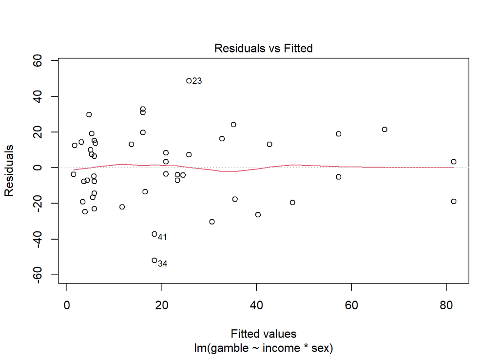

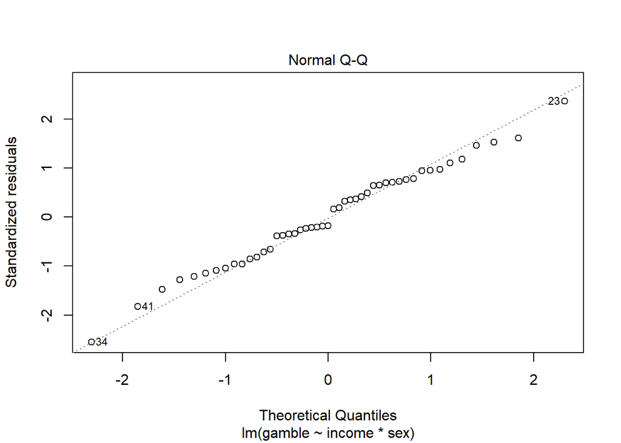

```r
#Creamos el modelo donde gamble depende de income y sex. Pero la operacion es multiplicar porque hay interacciones
teen_lm = lm(gamble ~ income * sex, teen)

# Dos formas de representar el mismo plot
plot(teen_lm, which = c(1, 2), ask=FALSE)
```

```
## For confidence bands and detrending, please install `qqplotr`.
```

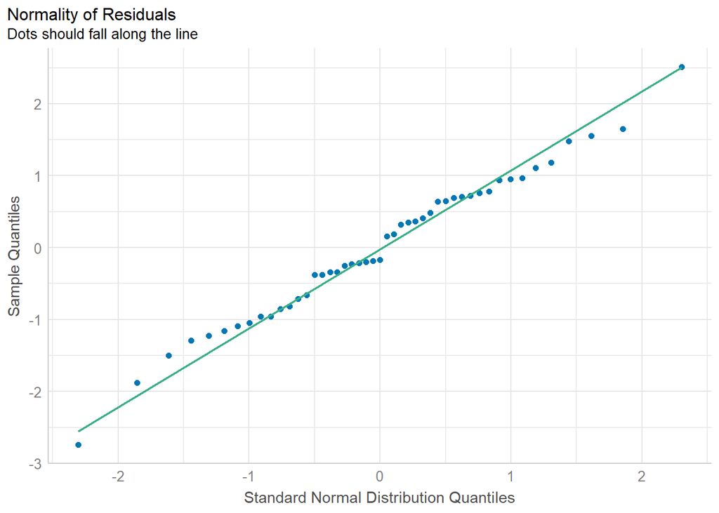

```r
plot(check_normality(teen_lm), "qq", detrend = TRUE)
```

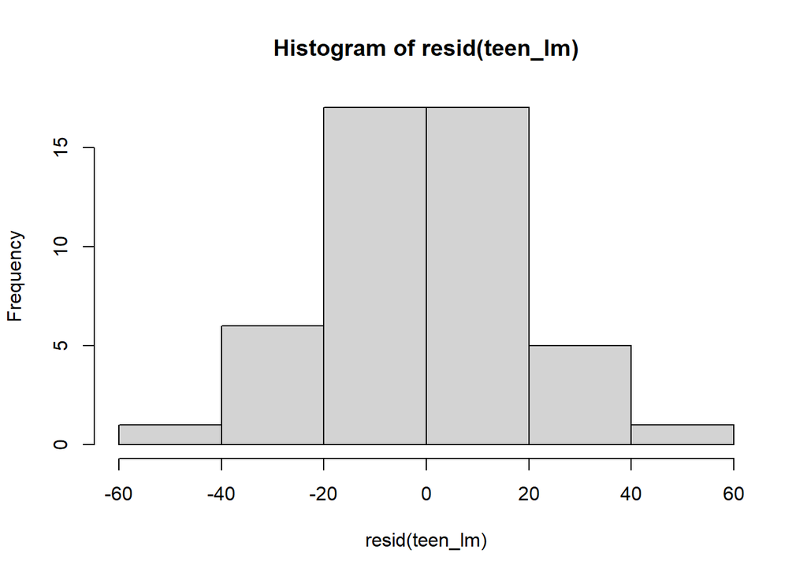

```r
hist(resid(teen_lm))
```

```r
# Obtenemos un resumen de nuestro modelo, al igual que os intervalos de confianza y el tamaño del efecto
summary(teen_lm) # --> nos da significativa la interaccion entre income y sexMale
```

```
##
## Call:
## lm(formula = gamble ~ income * sex, data = teen)
##
## Residuals:
##     Min      1Q  Median      3Q     Max
## -52.025 -15.479  -3.559  14.022  48.625
##
## Coefficients:
##                Estimate Std. Error t value Pr(>|t|)
## (Intercept)      6.8743     9.2446   0.744   0.4612
## income          -0.5489     1.9024  -0.289   0.7743
## sexMale          1.8427    11.1946   0.165   0.8700
## income:sexMale   5.4050     2.1435   2.522   0.0155 *
## ---
## Signif. codes:  0 '***' 0.001 '**' 0.01 '*' 0.05 '.' 0.1 ' ' 1
##
## Residual standard error: 20.97 on 43 degrees of freedom
## Multiple R-squared:  0.5105, Adjusted R-squared:  0.4764
## F-statistic: 14.95 on 3 and 43 DF,  p-value: 8.279e-07
```

```r
confint(teen_lm) # --> los intervalos de confianza estan por encima de 0 ambos [1.08, 9.72]
```

```
##                     2.5 %    97.5 %
## (Intercept)    -11.769152 25.517839
## income          -4.385455  3.287728
## sexMale        -20.733425 24.418773
## income:sexMale   1.082260  9.727751
```

```r
effectsize(teen_lm) # --> el efecto es de 0.66 [0.13, 1,19] para el metodo refit
```

```
## # Standardization method: refit
##
## Parameter      | Coefficient (std.) |         95% CI
## ----------------------------------------------------
## (Intercept)    |              -0.59 | [-0.93, -0.25]
## income         |              -0.07 | [-0.54,  0.40]
## sexMale        |               0.93 | [ 0.49,  1.37]
## income:sexMale |               0.66 | [ 0.13,  1.19]
```

```r
# Tambien observamos que el tamaño del efecto "ser hombre" es muy alto, pero de momento lo que sabemos es que hay interaccion entre apuestas e ingresos dependiendo del sexo, pero nada mas, por lo que necesitamos hacer estudios POST-Test
```

```r
#Sabemos que tiene interacciones, por lo que el post test con emmeans no nos sirve si no tenemos en cuenta la interaccion con sex. Sin embargo, y aunque no sea necesario, probamos para que nos lo dira de todas formas con un mensaje, y asi hacer doble check.
emmeans(teen_lm, "sex", adjust = "sidak") # --> No nos sirve
```

```
## NOTE: Results may be misleading due to involvement in interactions
```

```
##  sex    emmean   SE df lower.CL upper.CL
##  Female   4.33 4.90 43    -7.03     15.7
##  Male    31.26 3.98 43    22.04     40.5
##
## Confidence level used: 0.95
## Conf-level adjustment: sidak method for 2 estimates
```

```r
# RESULTADO:
# NOTE: Results may be misleading due to involvement in interactions


# Como dijimos anteriormente, es necesario incluir la variable sex.
teen_model_emms = emmeans(teen_lm, ~ sex | income ) %>% print
```

```
## income = 4.64:
##  sex    emmean   SE df lower.CL upper.CL
##  Female   4.33 4.90 43    -5.56     14.2
##  Male    31.26 3.98 43    23.24     39.3
##
## Confidence level used: 0.95
```

```r
# Lo que observamos ahora es que la media aumenta mas en hombres, teniendo un confidence level de [23.24, 39,3]. Mientras que en las mujeres es mas bajo y con intervalos de confianza que contienen el valor 0 (positivos y negativos)

teen_anova = Anova(teen_lm, type=3)
print(teen_anova)
```

```
## Anova Table (Type III tests)
##
## Response: gamble
##              Sum Sq Df F value  Pr(>F)
## (Intercept)   243.2  1  0.5530 0.46116
## income         36.6  1  0.0832 0.77434
## sex            11.9  1  0.0271 0.87003
## income:sex   2796.4  1  6.3585 0.01547 *
## Residuals   18910.9 43
## ---
## Signif. codes:  0 '***' 0.001 '**' 0.01 '*' 0.05 '.' 0.1 ' ' 1
```

```r
eta_squared(teen_anova)
```

```
## Type 3 ANOVAs only give sensible and informative results when covariates
##   are mean-centered and factors are coded with orthogonal contrasts (such
##   as those produced by 'contr.sum', 'contr.poly', or 'contr.helmert', but
##   *not* by the default 'contr.treatment').
```

```
## # Effect Size for ANOVA (Type III)
##
## Parameter  | Eta2 (partial) |       95% CI
## ------------------------------------------
## income     |       1.93e-03 | [0.00, 1.00]
## sex        |       6.30e-04 | [0.00, 1.00]
## income:sex |           0.13 | [0.01, 1.00]
##
## - One-sided CIs: upper bound fixed at (1).
```

### 3) Interpreta los coeficientes y escribe tus conclusiones.

**Conclusiones sobre las variables de interés**:

Las conclusiones que se pueden obtener a partir del modelo con interacciones se pueden observar en el grafico, y se mencionaron previamente.

confint(teen_lm) # –> los intervalos de confianza estan por encima de 0 ambos [1.08, 9.72], lo que nos indica que esta interaccion es significativa y que nuestro modelo nosda una dependencia entre la variablegamble y las variables sex/income

effectsize(teen_lm) # –> el efecto es de 0.66 [0.13, 1,19] para el metodo refit, lo que nos indica que fuerza tiene esa dependencia. En este caso no encontre la tabla “REFIT” para indicar si el valor de 0.13 es alto o no.

### 4) Crea un gráfico con las predicciones de tu modelo…

…y compáralas con los datos reales.

```r
teen$predictions = print(predict(teen_lm))
```

```
##         1         2         3         4         5         6         7         8
##  5.776616  5.502184  5.776616  3.032296  5.776616  4.969786  3.855592  3.350637
##         9        10        11        12        13        14        15        16
##  5.776616  3.581160  5.227752  4.267240  5.666843  5.776616  5.227752  6.051048
##        17        18        19        20        21        22        23        24
##  1.660136  1.385704  4.678888 25.713513 23.285442 20.857371 25.713513 57.278432
##        25        26        27        28        29        30        31        32
## 40.281937 16.001230 35.134427 13.573159 11.630702 35.425795 66.990715 42.710008
##        33        34        35        36        37        38        39        40
## 81.559139 18.429300 16.001230 30.569654 20.857371 47.566149 57.278432 16.486844
##        41        42        43        44        45        46        47
## 18.429300 81.559139 23.285442 24.499477 32.706356 16.001230 20.857371
```

```
## No summary function supplied, defaulting to `mean_se()`
## No summary function supplied, defaulting to `mean_se()`
```

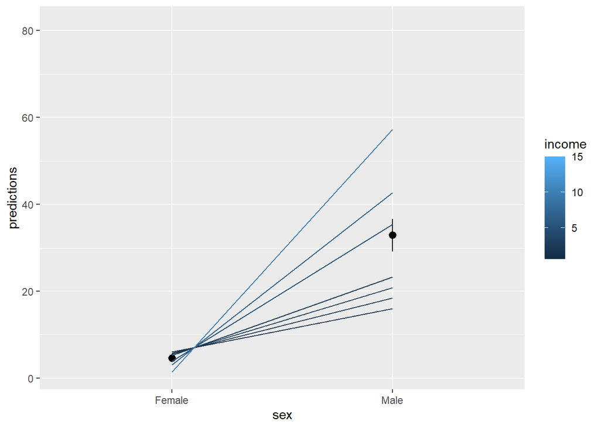

```r
ggplot(teen, aes(x=sex, y=predictions, col=income)) +
  stat_summary() +
  stat_summary(geom='line', aes(group=income))
```

```
## No summary function supplied, defaulting to `mean_se()`
## No summary function supplied, defaulting to `mean_se()`
```

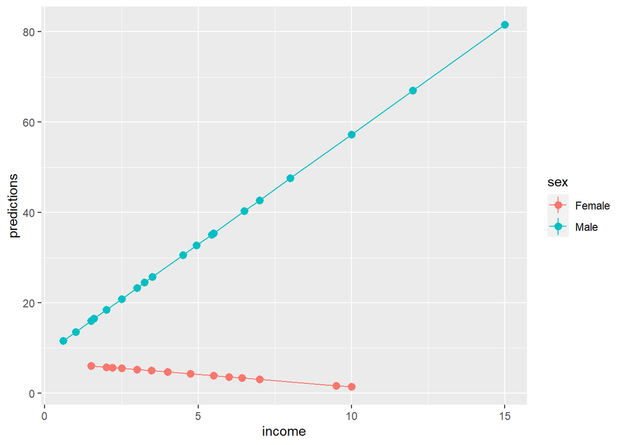

```r
ggplot(teen, aes(x=income, y=predictions, col=sex)) +
  stat_summary() +
  stat_summary(geom='line', aes(group=sex))
```

```r
#ggplot(teen, aes(x=gamble, y=predictions, col=sex)) +
#  stat_summary() +
#  stat_summary(geom='line', aes(group=sex))
```

### 5) Valora si las asunciones del modelo se cumplen

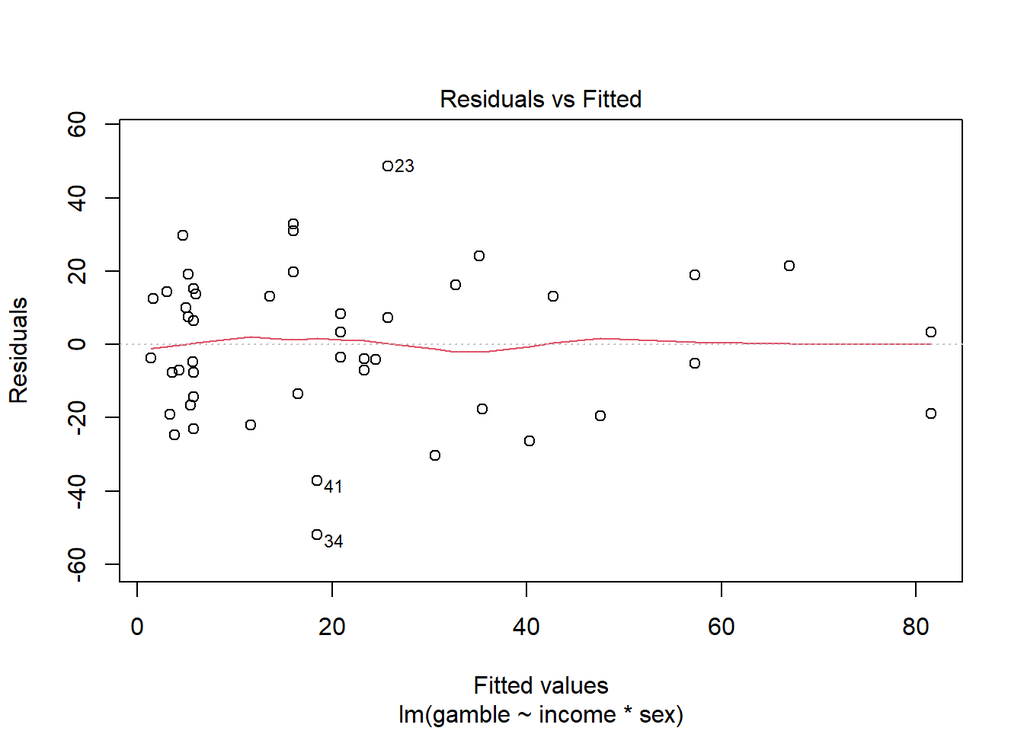

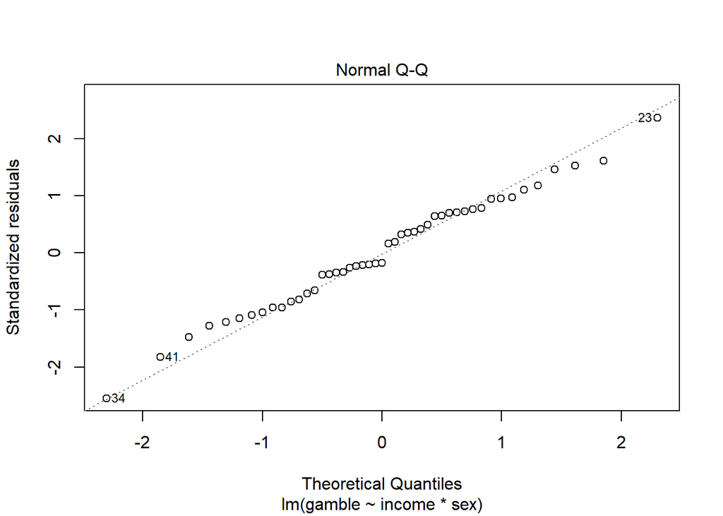

```r
# Como se menciono en la linea 83-85, los hombres tienden a apostar mas cuando aumentan los ingresos, por lo que el modelo lineal nos da un incremento de gamble cuando aumentamos income

# Sin embargo, tal y como se observaba en la figura, y tambien fue comentado en la linea 83-85, las mujeres son mas estables a la hora de apostar dependiendo el ingreso. Es por eso que en las predicciones vemos que las mujeres tienen una recta con menos pendiente, incluso llega a ser algo negativa, pero practicamente plana
plot(teen_lm, which = c(1, 2), ask=FALSE)
```

**¿Es el modelo correcto?:**

# Se podria decir que es aproximado, aunque no del todo perfecto

Los valores del QQ nos indica que estan todos dentro de la normalidad, pero cuando nos fijamos en los valores reales vs los predichos nos damos cuenta que en los hombres puede ajustarse aproximadamente a la realidad pero el de las mujeres es mucho mas imperfecto. Sin embargo, cuando vemos el modelo, tiene una grafica parecida a la que esperabamosen un inicio, solo que los valores, aunque normales, tienen mucha variabilidad, y esto se puede ver tambien en los “Residuals vs fitted”